# Time Series Analysis

Hameed Jimoh

2017-11-25

# 1.0 Introduction

A time series is a sequence of observations in progressive time order.

# Definitions

A series $\{X_{t1},X_{t2},...X_{tn}\}$ is Strictly stationary if $\{X_{t1},X_{t2},...X_{tn}\}$ has the same distribution as $\{X_{t1+h},X_{t2+h},...X_{tn+h}\}$.

Let ${X_t }$ be a time series with $E[X_{t}] < \infty$.

- The mean function of ${X_t}$ is $\mu_{X(t)} = E[X_t]$.
- The covariance function of $X_t$ is $γ{X(r, s)} = Cov(X_r,X_s) = E[(X_r − μ_{X(r)})(X_s − μ_{X(s)})]$, for all integers r and s.

Let {Xt } be a stationary time series. The autocovariance function (ACVF) of $X_t$ at lag $h$ is $γX(h) = Cov(Xt+h,Xt )$. The autocorrelation function (ACF) of $X_t$ at lag $h$ is $ρX(h) = γX(h)$, $γX(0)= Cor(X_{t+h},X_t )$.

If $X_{t}$ is strictly stationary, $E[X_{t}]= constant$ in $t$ and $ Cov(X_{t},X_{t+h})=constant$ in $t$.

A series {$X_{t}$} is called weak Stationary if

- $E[X_{t}]$ does not depend on t
- $Cov(X_{t},X_{t+h})$ does not depend on $t$. (for all h)

# Estimating and Eliminating Trend and Seasonal component.

To analyze time series data, we need to first plot the data. If there is any discontinuity in such a series, we break the series and analyze it piecewise. Then, we check for outliers by examining carefully whether there is any justification for discarding them. One possible method of representing the data is a classical decomposition model. $X_t = M_t + S_t + Z_t$ where $M_t$ represent the trend in the series S_t is the seasonal component with a known period and $Z_t$ is the noise component. Our aim in time series is to compute and isolate the deterministic components. $M_t$ and $S_t$ with the intention that the noise component $Z_t$ becomes a stationary time series. Then, we can find a satisfactory probabilistic model for $Z_t$ to compare the correlation structure and use it with M_t and S_t for prediction.

Box and Jenkins established another method. In their process, they suggest applying differencing operators repeatedly to the series $X_t$ until resulting series $W_t$ becomes stationary, we can find a probabilistic model to explain its correlation Structure. This model can be used for the prediction of $W_t$ and hence the original series.

# 2.0 Methodology

DIFFERENCING

We define the lag-d difference operator $\nabla$ by $\nabla = X_{t} - X_{t-d} = (1 - B^{d})X_{t}$ where $B$ is the backward Shift operator.

Applying this operator to the model $X_{t} = M_{t} + S_{t} + Z_{t}$ where $S_{t}$ has a period of d, we get; $X_{t} = M_{t}-M_{t-d} + Z_{t} - Z_{t-d}$

$∇dXt = Xt − Xt−d = (1 − Bd)Xt$.

Trend and/or seasonal components are removed by repeatedly differencing the data at one or more lag in order to generate a noise sequence.

#3.0 Example

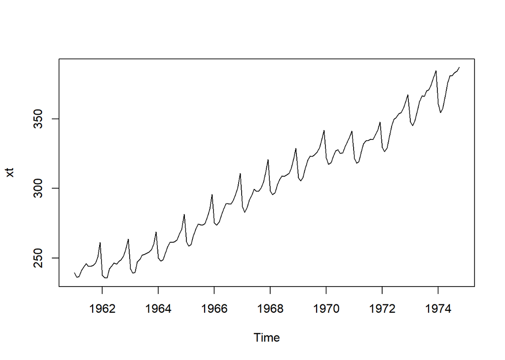

Next we plot the ACF and PACF graph of the data

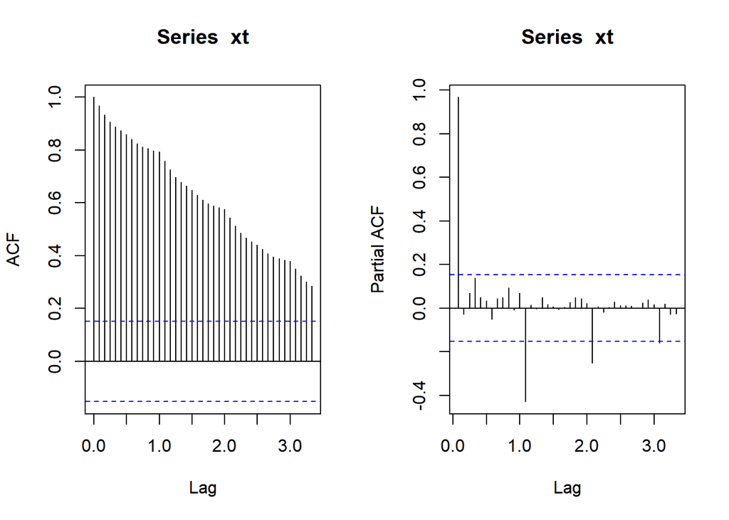

The data needs to be transformed, so we use BoxCox transformation. To use BoxCox, we need to find the best lambda that will optimize the data, so we plot the graph, obtain the optimal lambda, and use it to transform the data.

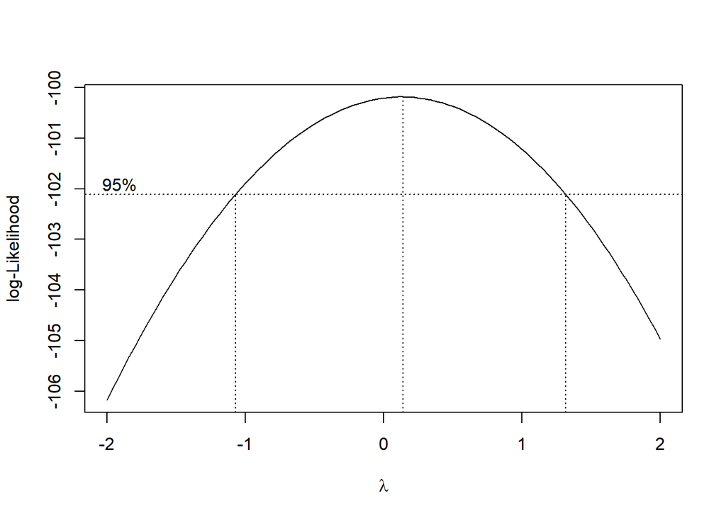

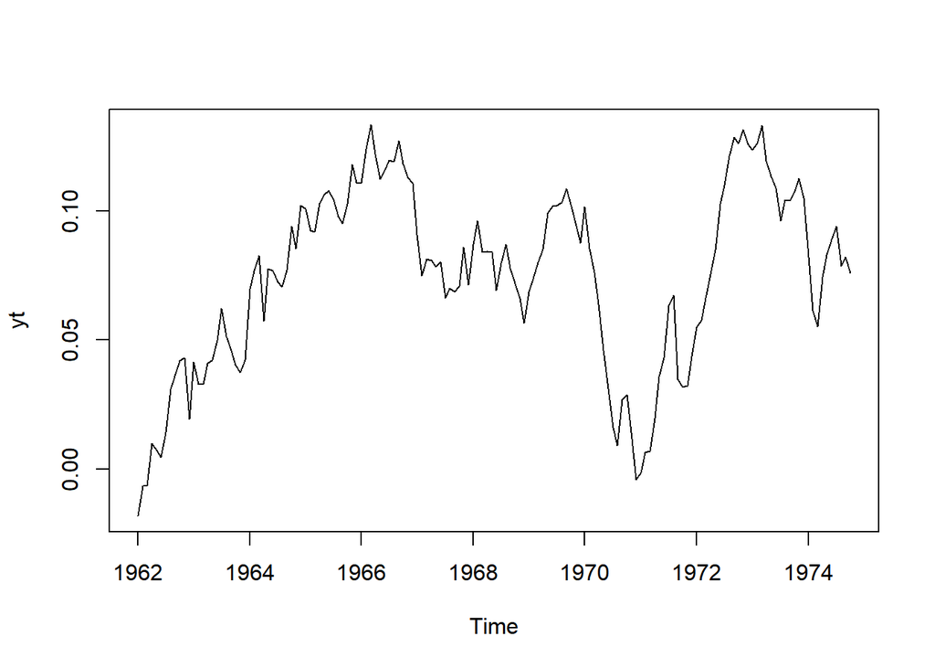

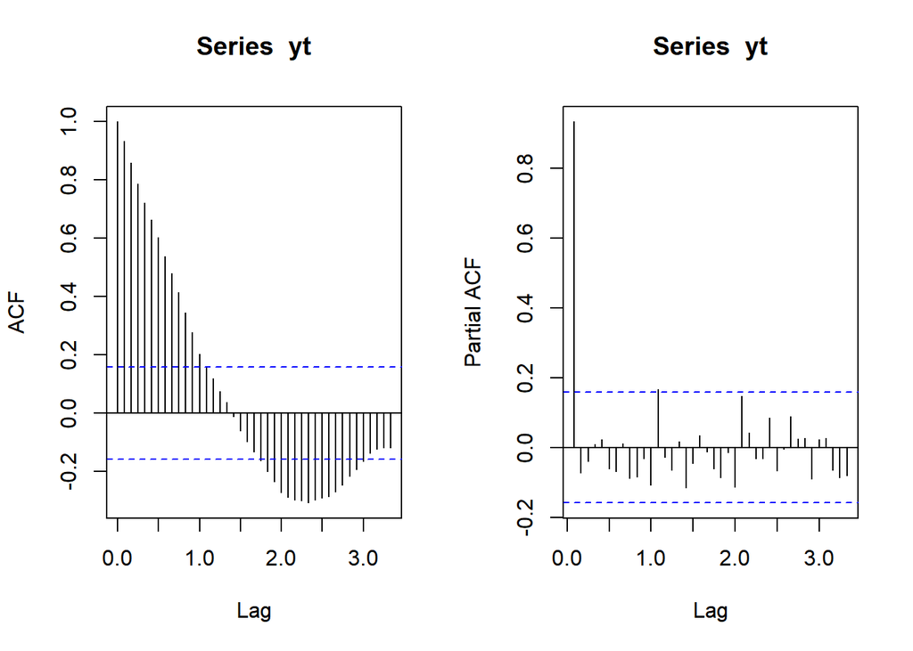

The model with least AICc value is

SARIMA(1,0,0)(0,1,1)12 Model. To test if any of our model parameters can be dropped, we perform a T-test on each of the parameters and compare their respective p-values to our level of significance;

```
##       ar1      sma1     drift
## 53.286237 -3.262842  3.005449
```

```
##           ar1          sma1         drift
## 4.858264e-105  1.343721e-03  3.071472e-03
```

To check for the adequacy of this model, we performed some diagnostic tests on it. First, we plot the residue to check whether there is a change in variance for our model.

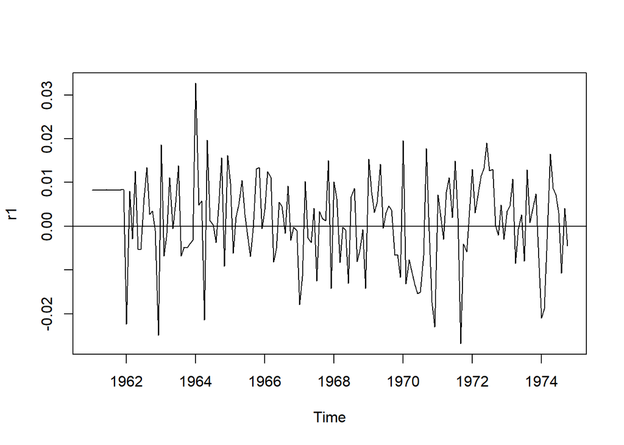

No particular pattern was observed in the residual plot, so we can say that the equal variance assumption required for model building is satisfied.

Next, we carry out a series of tests to check whether the residuals are White Niose (IID). First we carry out the Ljung-Box Test and obtain the p-value

```
##
##  Box-Ljung test
##
## data:  r1
## X-squared = 31.142, df = 40, p-value = 0.841
```

Since our p-value is greater than 0.05, hence we have that (by Ljung-Box test) the residuals are White Noise (IID).

```
##
##  Turning Point Test
##
## data:  r1
## statistic = -1.7275, n = 166, p-value = 0.08407
## alternative hypothesis: non randomness
```

```
##
##  Difference Sign Test
##
## data:  r1
## statistic = 0.40209, n = 166, p-value = 0.6876
## alternative hypothesis: nonrandomness
```

```
##
##  Mann-Kendall Rank Test
##
## data:  r1
## statistic = -1.6157, n = 166, p-value = 0.1062
## alternative hypothesis: trend
```

Finally, we check the normality of this residue; we do this by plotting the QQ-normal plot and the Shapiro-Wilk test.

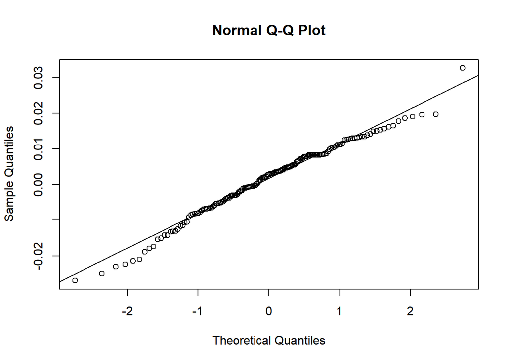

```
##
##  Shapiro-Wilk normality test
##
## data:  r1
## W = 0.98444, p-value = 0.06039
```

The p-value of the Shapiro-Wilk test is greater than 0.05. Thus, the normal residue assumption is satisfied.

# 4.0 Discussion and Results

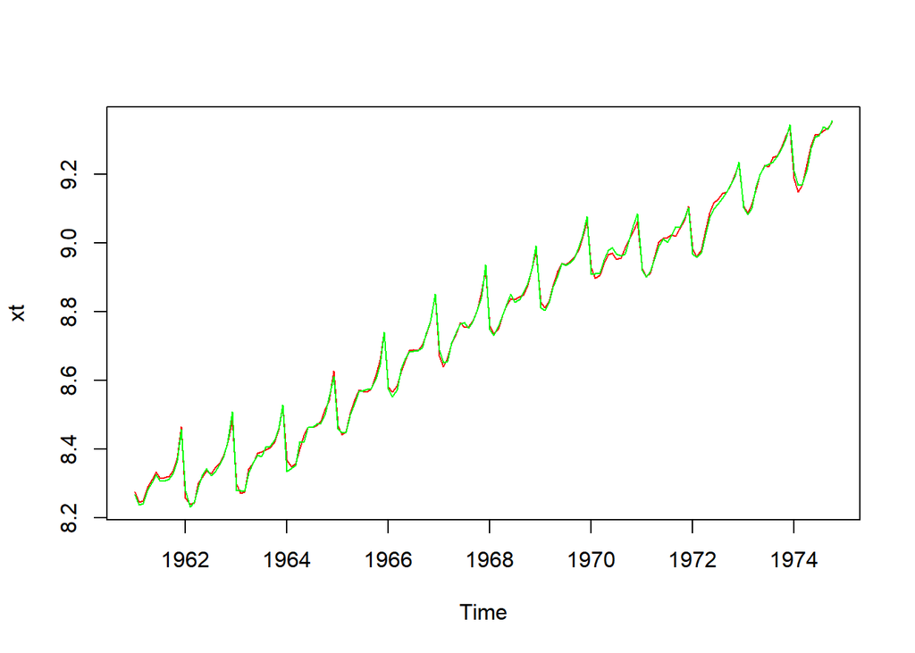

```
##          Point Forecast    Lo 80    Hi 80    Lo 95    Hi 95
## Nov 1974       9.383691 9.370090 9.397292 9.362889 9.404493
## Dec 1974       9.412413 9.393396 9.431430 9.383330 9.441497
## Jan 1975       9.269859 9.246831 9.292887 9.234641 9.305077
## Feb 1975       9.235504 9.209211 9.261797 9.195293 9.275715
## Mar 1975       9.255267 9.226197 9.284337 9.210809 9.299726
## Apr 1975       9.310564 9.279070 9.342058 9.262398 9.358729
## May 1975       9.361544 9.327898 9.395189 9.310087 9.413000
## Jun 1975       9.391398 9.355819 9.426977 9.336985 9.445811
## Jul 1975       9.391373 9.354041 9.428704 9.334279 9.448466
## Aug 1975       9.405375 9.366444 9.444306 9.345835 9.464915
## Sep 1975       9.411638 9.371239 9.452038 9.349853 9.473424
## Oct 1975       9.428989 9.387236 9.470742 9.365133 9.492845
```

```
##           Jan      Feb      Mar      Apr      May      Jun      Jul      Aug
## 1974
## 1975 9.272166 9.249827 9.267218 9.315689 9.368676 9.396557 9.393014 9.410684
##           Sep      Oct      Nov      Dec
## 1974                   9.379388 9.404807
## 1975 9.411858 9.424738
```